# Analysis 1 Solutions: UNC Salaries

Mario Giacomazzo

July 07, 2021

# Instructions

**Overview:** For each question, show your R code that you used to answer each question in the provided chunks. When a written response is required, be sure to answer the entire question in complete sentences outside the code chunks. When figures are required, be sure to follow all requirements to receive full credit. Point values are assigned for every part of this analysis.

**Helpful:** Make sure you knit the document as you go through the assignment. Check all your results in the created HTML file.

**Submission:** Submit via an electronic document on Sakai. Must be submitted as an HTML file generated in RStudio.

# Introduction

Universities are typically opaque, bureaucratic institutions. To be transparent to tax payers, many public schools, such as the University of North Carolina, openly report **[salary information](http://www.newsobserver.com/news/databases/public-salaries/)**. In this assignment, we will analyze this information from 2017 to answer pivotal questions that have endured over the course of time. The most recent salary data for UNC-Chapel Hill faculty and staff has already been downloaded in CSV format and titled *“UNC_System_Salaries Search and Report.csv”*. If you scan the spreadsheet, you will notice that Dr. Mario is not listed. People get depressed when they see that many digits after the decimal.

To answer all the questions, you will need the R package `tidyverse` to make figures and utilize `dplyr` functions.

# Data Information

Make sure the CSV data file is contained in the folder of your RMarkdown file. First, we start by using the `read_csv` function from the `readr` package found within the tidyverse. The code below executes this process by creating a tibble in your R environment named “salary”.

```r
salary=read_csv("UNC_System_Salaries Search and Report.csv")
```

Now, we will explore the information that is contained in this dataset. The code below provides the names of the variables contained in the dataset.

```r
names(salary)
```

```
##  [1] "Name"                  "campus2"               "dept"
##  [4] "position"              "PRIMARY_WORKING_TITLE" "hiredate"
##  [7] "exempt"                "fte"                   "employed"
## [10] "statesal"              "nonstsal"              "totalsal"
## [13] "stservyr"
```

Next, we will examine the type of data contains in these different variables.

```r
str(salary,give.attr=F)
```

```
## tibble [12,646 x 13] (S3: spec_tbl_df/tbl_df/tbl/data.frame)
##  $ Name                 : chr [1:12646] "AACHOUI, YOUSSEF" "AARNIO, REA T" "ABAJAS, YASMINA L" "ABARBANELL, JEFFERY S" ...
##  $ campus2              : chr [1:12646] "UNC-CHAPEL HILL" "UNC-CHAPEL HILL" "UNC-CHAPEL HILL" "UNC-CHAPEL HILL" ...
##  $ dept                 : chr [1:12646] "Microbiology and Immunology" "SW-Research Projects" "Peds-Hematology/Oncology" "Kenan-Flagler Bus Sch" ...
##  $ position             : chr [1:12646] "Research Professional, Medical" "Functional Paraprofessional" "Assistant Professor" "Associate Professor" ...
##  $ PRIMARY_WORKING_TITLE: chr [1:12646] "Research Associate" "Graphic Designer" "NODESCR" "Associate Professor" ...
##  $ hiredate             : chr [1:12646] "10/10/2011" "1/14/2013" "7/1/2015" "1/1/1999" ...
##  $ exempt               : chr [1:12646] "Exempt from Personnel Act" "Subject to State Personnel Act" "Exempt from Personnel Act" "Exempt from Personnel Act" ...
##  $ fte                  : num [1:12646] 1 0.8 1 1 1 1 1 1 1 1 ...
##  $ employed             : num [1:12646] 12 12 12 9 12 12 12 9 12 9 ...
##  $ statesal             : logi [1:12646] NA NA NA NA NA NA ...
##  $ nonstsal             : logi [1:12646] NA NA NA NA NA NA ...
##  $ totalsal             : num [1:12646] 49128 33257 139405 181000 41098 ...
##  $ stservyr             : num [1:12646] 1 5 2 20 6 8 6 1 19 1 ...
```

You will notice that the variable “hiredate” is recorded as a character. The following code will first modify the original dataset to change this to a date variable with the format *yyyy-mm-dd*. Then, we will remove the hyphens to create a numeric variable as *yyyymmdd*. Finally, in the spirit of tidyverse, we will convert this data frame to a tibble

```r
salary$hiredate=as.Date(salary$hiredate, "%m/%d/%Y")
salary$hiredate=as.numeric(gsub("-","",salary$hiredate))
salary=as.tibble(salary)
```

Now, we will use `head()` to view of first five rows and the modifications made to the original data. The rest of the assignment will extend off this modified dataset named `salary` which by now should be in your global environment.

```r
head(salary,5)
```

```
## # A tibble: 5 x 13
##   Name  campus2 dept  position PRIMARY_WORKING~ hiredate exempt   fte employed
##   <chr> <chr>   <chr> <chr>    <chr>               <dbl> <chr>  <dbl>    <dbl>
## 1 AACH~ UNC-CH~ Micr~ Researc~ Research Associ~ 20111010 Exemp~   1         12
## 2 AARN~ UNC-CH~ SW-R~ Functio~ Graphic Designer 20130114 Subje~   0.8       12
## 3 ABAJ~ UNC-CH~ Peds~ Assista~ NODESCR          20150701 Exemp~   1         12
## 4 ABAR~ UNC-CH~ Kena~ Associa~ Associate Profe~ 19990101 Exemp~   1          9
## 5 ABAR~ UNC-CH~ Inst~ Researc~ Research Techni~ 20110912 Subje~   1         12
## # ... with 4 more variables: statesal <lgl>, nonstsal <lgl>, totalsal <dbl>,
## #   stservyr <dbl>
```

# Assignment

## Part 1: Reducing the Data to a Smaller Set of Interest

### Q1 *(2 Points)*

Create a new dataset named `salary2` that only contains the following variables:

- “Name”
- “dept”
- “position”
- “hiredate”
- “exempt”
- “totalsal”

Then, use the `names()` function to display the variable names of `salary2`.

```r
salary2=select(salary,"Name","dept","position","hiredate","exempt","totalsal")
names(salary2)
```

```
## [1] "Name"     "dept"     "position" "hiredate" "exempt"   "totalsal"
```

### Q2 *(2 Points)*

Now, we modify `salary2`. Rename the variables “dept”,“position”,“exempt”,“totalsal” to “Department”,“Job”,“Exempt”, and “Salary”, respectively. Do this for a new dataset called `salary3` and use `names()` to display the variable names of `salary3`.

```r
salary3=rename(salary2,Department=dept,Job=position,Exempt=exempt,Salary=totalsal)
names(salary3)
```

```
## [1] "Name"       "Department" "Job"        "hiredate"   "Exempt"
## [6] "Salary"
```

### Q3 *(2 Points)*

Now, we modify `salary3`. Create a new variable called “HireYear” that only contains the first four digits of the variable “hiredate” in a new dataset named `salary4`. Use the function `str()` to ensure that your new variable “HireYear” reports the year of the date that the employee was hired.

```r
salary4=mutate(salary3,HireYear=hiredate %/% 10000)
str(salary4)
```

```
## tibble [12,646 x 7] (S3: tbl_df/tbl/data.frame)
##  $ Name      : chr [1:12646] "AACHOUI, YOUSSEF" "AARNIO, REA T" "ABAJAS, YASMINA L" "ABARBANELL, JEFFERY S" ...
##  $ Department: chr [1:12646] "Microbiology and Immunology" "SW-Research Projects" "Peds-Hematology/Oncology" "Kenan-Flagler Bus Sch" ...
##  $ Job       : chr [1:12646] "Research Professional, Medical" "Functional Paraprofessional" "Assistant Professor" "Associate Professor" ...
##  $ hiredate  : num [1:12646] 20111010 20130114 20150701 19990101 20110912 ...
##  $ Exempt    : chr [1:12646] "Exempt from Personnel Act" "Subject to State Personnel Act" "Exempt from Personnel Act" "Exempt from Personnel Act" ...
##  $ Salary    : num [1:12646] 49128 33257 139405 181000 41098 ...
##  $ HireYear  : num [1:12646] 2011 2013 2015 1999 2011 ...
##  - attr(*, "spec")=
##   .. cols(
##   ..   Name = col_character(),
##   ..   campus2 = col_character(),
##   ..   dept = col_character(),
##   ..   position = col_character(),
##   ..   PRIMARY_WORKING_TITLE = col_character(),
##   ..   hiredate = col_character(),
##   ..   exempt = col_character(),
##   ..   fte = col_double(),
##   ..   employed = col_double(),
##   ..   statesal = col_logical(),
##   ..   nonstsal = col_logical(),
##   ..   totalsal = col_double(),
##   ..   stservyr = col_double()
##   .. )
```

### Q4 *(2 points)*

Now, we modify `salary4`. Create a new variable called “YrsEmployed” which reports the number of full years the employee has worked at UNC. Use 2017 as the current year and assume that all employees are hired January 1. Create a new dataset named `salary5` and again use `str()` to display the variables in `salary5`.

```r
salary5=mutate(salary4,YrsEmployed=2017-HireYear)
str(salary5)
```

```
## tibble [12,646 x 8] (S3: tbl_df/tbl/data.frame)
##  $ Name       : chr [1:12646] "AACHOUI, YOUSSEF" "AARNIO, REA T" "ABAJAS, YASMINA L" "ABARBANELL, JEFFERY S" ...
##  $ Department : chr [1:12646] "Microbiology and Immunology" "SW-Research Projects" "Peds-Hematology/Oncology" "Kenan-Flagler Bus Sch" ...
##  $ Job        : chr [1:12646] "Research Professional, Medical" "Functional Paraprofessional" "Assistant Professor" "Associate Professor" ...
##  $ hiredate   : num [1:12646] 20111010 20130114 20150701 19990101 20110912 ...
##  $ Exempt     : chr [1:12646] "Exempt from Personnel Act" "Subject to State Personnel Act" "Exempt from Personnel Act" "Exempt from Personnel Act" ...
##  $ Salary     : num [1:12646] 49128 33257 139405 181000 41098 ...
##  $ HireYear   : num [1:12646] 2011 2013 2015 1999 2011 ...
##  $ YrsEmployed: num [1:12646] 6 4 2 18 6 8 5 1 12 1 ...
##  - attr(*, "spec")=
##   .. cols(
##   ..   Name = col_character(),
##   ..   campus2 = col_character(),
##   ..   dept = col_character(),
##   ..   position = col_character(),
##   ..   PRIMARY_WORKING_TITLE = col_character(),
##   ..   hiredate = col_character(),
##   ..   exempt = col_character(),
##   ..   fte = col_double(),
##   ..   employed = col_double(),
##   ..   statesal = col_logical(),
##   ..   nonstsal = col_logical(),
##   ..   totalsal = col_double(),
##   ..   stservyr = col_double()
##   .. )
```

### Q5 *(4 points)*

Now, we modify `salary5` to create our final dataset named `salary.final`. Use the pipe `%>%` to make the following changes:

- Drop the variables “hiredate” and “HireYear”.
- Sort the observations first by “YrsEmployed” and then by “Department”.
- Rearrange the variables so that “YrsEmployed” and “Salary” are the first two variables in the dataset, in that order, without removing any of the other variables.

After you have used the `%>%` to make these changes, use the function `head()` to display the first 10 rows of `salary.final`.

```r
salary.final = salary5 %>%
  select(-hiredate,-HireYear) %>%
  arrange(YrsEmployed,Department) %>%
  select(YrsEmployed,Salary,everything())
head(salary.final,10)
```

```
## # A tibble: 10 x 6
##    YrsEmployed Salary Name       Department     Job                Exempt
##          <dbl>  <dbl> <chr>      <chr>          <chr>              <chr>
##  1           0  39646 DALEY, JO~ A and S - Bus~ Fiscal Affairs Pa~ Subject to S~
##  2           0  48814 WEBSTER, ~ A and S - Bus~ HR Coordinator     Subject to S~
##  3           0  48814 WOODSON, ~ A and S - Bus~ HR Coordinator     Subject to S~
##  4           0  48814 WORTHEN, ~ A and S - Bus~ HR Coordinator     Subject to S~
##  5           0  47476 JONES, CL~ Academic Advi~ Academic Advising~ Exempt from ~
##  6           0  58000 MITCHALL,~ Academic Advi~ Academic Advising~ Exempt from ~
##  7           0  47476 RICHARDS,~ Academic Advi~ Academic Advising~ Exempt from ~
##  8           0  47476 VIRAY, JE~ Academic Advi~ Academic Advising~ Exempt from ~
##  9           0  60000 WALDIE, A~ Academic Advi~ Academic Advising~ Exempt from ~
## 10           0  65000 ALLEN, DA~ Accounting Se~ Accounting Profes~ Subject to S~
```

## Part 2: Answering Questions Based on All Data

### Q6 *(2 Points)*

What is the average salary of employees in the Law Department?

Code *(1 Point)*:

```r
salary.final %>%
  filter(Department=="Law") %>%
  summarize(mean(Salary))
```

```
## # A tibble: 1 x 1
##   `mean(Salary)`
##            <dbl>
## 1        112567.
```

Answer *(1 Point)*: The average salary for employees in Law is $112,567.10.

### Q7 *(4 Points)*

How many employees have worked in Family Medicine between 5 and 8 years (inclusive) and are exempt from personnel act?

Code *(2 Points)*:

```r
salary.final %>%
  filter(Department=="Family Medicine",YrsEmployed>=5,YrsEmployed<=8,Exempt=="Exempt from Personnel Act") %>%
  summarize(count=n())
```

```
## # A tibble: 1 x 1
##   count
##   <int>
## 1    10
```

Answer *(2 Points)*: There are 10 employees who have worked in Family Medicine between 5 and 8 years (inclusive) and are exempt from personnel act.

### Q8 *(4 Points)*

What is the mean salary of employees from the Linguistics department who are professors, associate professors, or assistant professors?

Code *(2 Points)*:

```r
salary.final %>%
  filter(Department=="Linguistics" & Job %in% c("Professor","Associate Professor","Assistant Professor")) %>%
  summarize(mean(Salary))
```

```
## # A tibble: 1 x 1
##   `mean(Salary)`
##            <dbl>
## 1         79935.
```

Answer *(2 Points)*: The mean salary of employees from the Linguistics department who are professors, associate professors, or assistant professors is $79,935.17.

## Part 3: Answering Questions Based on Summarized Data

### Q9 *(4 Points)*

Based off the data in `salary.final`, create a grouped summary based off combinations of “Department” and “YrsEmployed”. Call the new tibble `deptyear_summary`. Your summarized tibble, `deptyear_summary`, should report all of the following statistics with corresponding variable names in the following order.

- “n” = number of employees for each combination
- “mean” = average salary for each combination
- “sd” = standard deviation of salary for each combination.
- “min” = minimum salary for each combination.
- “max” = maximum salary for each combination

In the process, make sure you use `ungroup()` with the pipe `%>%` to release the grouping so future work is no longer group specific. Following the creation of `deptyear_summary`, prove that your code worked by using `head()` to view the first 10 rows.

```r
deptyear_summary=salary.final %>%
                group_by(Department,YrsEmployed) %>%
                summarize(n=n(),mean=mean(Salary),sd=sd(Salary),min=min(Salary),max=max(Salary)) %>%
                ungroup()
head(deptyear_summary,10)
```

```
## # A tibble: 10 x 7
##    Department                YrsEmployed     n   mean     sd   min   max
##    <chr>                           <dbl> <int>  <dbl>  <dbl> <dbl> <dbl>
##  1 A and S - Business Center           0     4 46522   4584  39646 48814
##  2 A and S - Business Center           1     4 43610.  4589. 39646 47983
##  3 A and S - Business Center           2     2 48398.   588. 47983 48814
##  4 A and S - Business Center           3     2 52190.  2703. 50278 54101
##  5 A and S - Business Center           4     2 54488   9199. 47983 60993
##  6 Acad Initiatives-UBC                1     1 23250     NA  23250 23250
##  7 Acad Initiatives-UBC                3     1 48782     NA  48782 48782
##  8 Acad Initiatives-UBC                6     1 60341     NA  60341 60341
##  9 Acad Initiatives-UBC                7     1 54851     NA  54851 54851
## 10 Acad Initiatives-UBC               14     2 64916  12875. 55812 74020
```

### Q10 *(4 Points)*

Using the summarized data in `deptyear_summary`, use the `dplyr` functions to identify the 5 departments that award the lowest average salary for employees who have been employed for 3 years. The output should only show the 5 departments along with the corresponding years employed, which should all be 3, and the four summarizing statistics created.

Furthermore, explain why the standard deviation for at least one of the 5 departments in your list has a salary standard deviation of “NA” or “NaN”. What does this mean and how did it occur?

Code *(2 Points)*:

```r
deptyear_summary %>%
  filter(YrsEmployed==3) %>%
  arrange(mean) %>%
  filter(min_rank(mean)<=5)
```

```
## # A tibble: 5 x 7
##   Department                    YrsEmployed     n   mean    sd    min    max
##   <chr>                               <dbl> <int>  <dbl> <dbl>  <dbl>  <dbl>
## 1 TEACCH - Supported Employment           3     2 26041. 5261. 22321  29761.
## 2 DPS Security                            3     3 26569. 6896. 18627. 31047.
## 3 FS-Housekeeping Svcs-Zone 13            3     1 26680.   NA  26680. 26680.
## 4 FS-Housekeeping Svcs-Zone 16            3     1 26680.   NA  26680. 26680.
## 5 FS-Housekeeping Svcs-Zone 18            3     2 26680.    0  26680. 26680.
```

Answer *(2 Points)*: The standard deviation is irrelevant when there is only 1 observation. To measure the spread you need at least 2 observations.

### Q11 *(4 points)*

Create a scatter plot using `geom_point()` along with fitted lines using `geom_smooth` with the argument `method="lm"` showing the linear relationship between average salary and the years employeed. For this plot, use the summarized data in `deptyear_summary`. Following the plot, please explain what this plot suggests about the relationship between the salary a UNC employee makes and how many years that employee has served. Make reference to the figure and use descriptive adjectives (i.e. “strong”, “weak”, etc.) and terms (i.e. “positive”, “negative”, etc.) that are appropriate for discussing linear relationships.

Code and Figure *(2 Points)*:

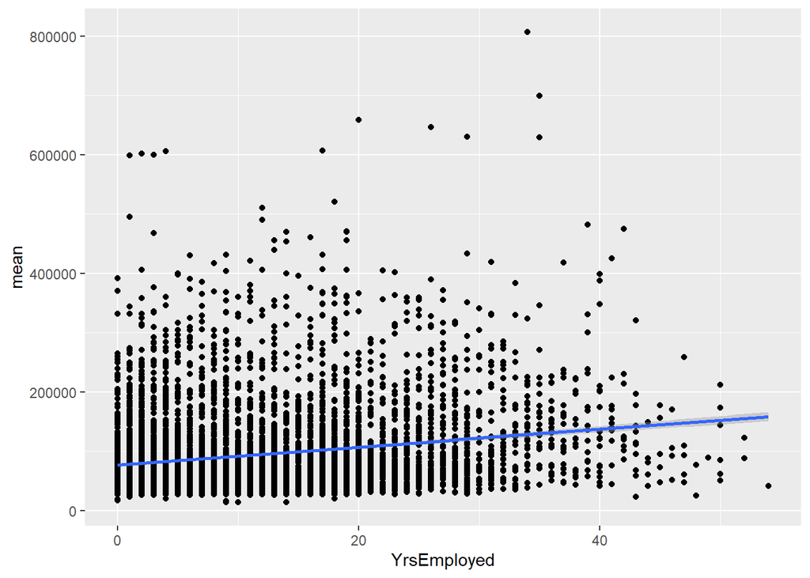

```r
ggplot(data=deptyear_summary) +
  geom_point(aes(x=YrsEmployed,y=mean)) +
  geom_smooth(aes(x=YrsEmployed,y=mean),method="lm")
```

Answer *(2 Points)*: Based on the combined scatter plot and fitted regression line, there seems to be a weak positive linear relationship between the years employed and the average salary.

### Q12 *(6 Points)*

Code and Figure: *(3 Points)*:

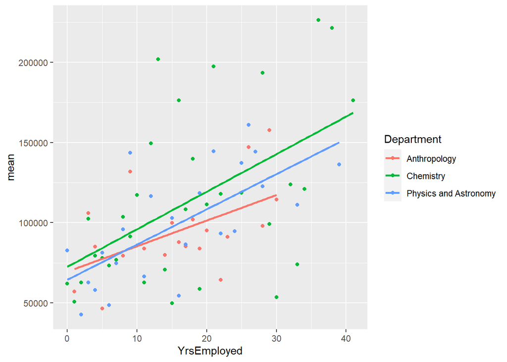

```r
ggplot(data=filter(deptyear_summary, Department %in% c("Chemistry","Anthropology","Physics and Astronomy"))) +
  geom_point(aes(x=YrsEmployed,y=mean,color=Department))+
  geom_smooth(aes(x=YrsEmployed,y=mean,color=Department), method="lm",se=F)
```

Answer *(3 Points)*: For my comparison, I chose the Anthropology, Chemistry, and Physics/Astronomy departments. From the regression lines, it seems that professors from anthropology, chemistry, and physics/astronomy have similar starting salaries and upward trajectories. Although the starting salary for chemistry is slightly higher than the starting salary for physics/astronomy, the rate at which salaries increase based on years employeed seems almost identical between the two departments. For anthropology, the rate at which salary increases is slower than the two STEM fields.